# Parte 3: Predição

Luiz Fonseca

7 de dezembro de 2016

Primeiro vamos carregar os dados e bibliotecas que serão utilizados.

```r
library(dplyr)
library(ggplot2)
library(reshape2)
library(caret)
library(leaps)

students.train.data <- read.csv("data/graduados_treino.csv")
students.test.data <- read.csv("data/graduados_teste.csv")

# set.seed(825) Para reproduzir os resultados
```

## Entendendo o problema e os dados

O objetivo deste exercício é construir modelos preditivos de regressão utilizando técnicas de regularização e seleção de variáveis para a predição do CRA baseados nas disciplinas do primeiro e segundo semestres. Os dados são sobre os alunos do Curso de Ciência da Computação da Universidade Federal de Campina Grande. Os dados fornecidos foram divididos em dados de treinos e de teste. Os dados de teste são cronologicamente posteriores aos dados de treino para que dessa forma podemos prever o “futuro” com base no passado.

## Preprocessamento dos dados

```r
preProcessModelInput <- function(dataframe) {
  # Renomea as colunas
  names(dataframe) <- c("matricula", "ano_formatura", "periodo_formatura",
                                "cod_disciplina", "disciplina", "creditos", "media")
  # Retira os valores NA das médias
  dataframe <- dataframe %>%
  filter(!is.na(media))

  # Calcula o CRA de cada aluno
  dataframe.cra <- dataframe %>%
  group_by(matricula) %>%
  mutate(cra.contrb = media*creditos) %>%
  summarise(cra = round(sum(cra.contrb)/sum(creditos), 2))

  disciplinas.iniciais <- c(
  "Cálculo Diferencial e Integral I",
  "Álgebra Vetorial e Geometria Analítica",
  "Leitura e Produção de Textos",
  "Programação I",
  "Introdução à Computação",
  "Laboratório de Programação I",
  "Cálculo Diferencial e Integral II",
  "Matemática Discreta",
  "Programação II",
  "Teoria dos Grafos",
  "Fundamentos de Física Clássica",
  "Laboratório de Programação II"
  )

  # Transforma o dataframe em um formato ideal para ser utilizado como entrada do modelo
  dataframe <- dataframe %>%
  filter(disciplina %in% disciplinas.iniciais) %>%
  group_by(matricula,disciplina)  %>%
  filter(media == max(media)) %>%
  ungroup() %>%
  select(matricula,disciplina,media) %>%
  mutate(disciplina = as.factor(gsub(" ",".",disciplina))) %>%
  dcast(matricula ~ disciplina, mean) %>%
  merge(dataframe.cra) %>%
  na.omit()

  return(dataframe)
}

students.train.data <- students.train.data %>% preProcessModelInput()
students.test.data <- students.test.data %>% preProcessModelInput()
```

## Atividades

1. **Usando todas as variáveis disponíveis (disciplinas do primeiro e segundo período), use validação cruzada (nos dados de treino) para tunar um modelo de regressão Ridge.**

Será utilizado o pacote caret, que implementa funções para tunar modelos usando o método ridge, lasso ou outros. Será utilizada uma validação cruzada 10-fold.

Explicação sobre a regressão Ridge:

A grande vantagem do método ridge é que através dele podemos diminuir a variância do modelo ao custo de um pequeno aumento no BIAS. O método ridge tende a aproximar os coeficientes das variáveis preditoras de 0, conforme o lambda aumenta. Isso diminui a flexibilidade do modelo, diminuindo também a variância, porém aumentando o BIAS. A ideia por trás da regressão Ridge é encontrar um lambda que gere um trade-off satisfatório entre BIAS e Variância.

```r
# library(caret)
fitControl <- trainControl(method = "cv",
                           number = 10)

lambdaGrid <- expand.grid(lambda = 10^seq(10, -2, length=100))

ridge.fit <- train(form = cra ~.,
                   data = students.train.data %>% select(-matricula),
                   trControl = fitControl,
                   method = 'ridge',
                   tuneGrid = lambdaGrid,
                   preProcess = c('scale', 'center'),
                   na.action = na.omit)

ridge.fit
```

```
## Ridge Regression
##
## 88 samples
## 12 predictors
##
## Pre-processing: scaled (12), centered (12)
## Resampling: Cross-Validated (10 fold)
## Summary of sample sizes: 79, 78, 78, 79, 80, 80, ...
## Resampling results across tuning parameters:
##
##   lambda        RMSE       Rsquared
##   1.000000e-02  0.5666946  0.5831063
##   1.321941e-02  0.5661868  0.5839729
##   1.747528e-02  0.5655448  0.5850834
##   2.310130e-02  0.5647445  0.5864933
##   3.053856e-02  0.5637645  0.5882632
##   4.037017e-02  0.5625930  0.5904539
##   5.336699e-02  0.5612371  0.5931193
##   7.054802e-02  0.5597388  0.5962965
##   9.326033e-02  0.5581984  0.5999934
##   1.232847e-01  0.5568109  0.6041757
##   1.629751e-01  0.5559224  0.6087553
##   2.154435e-01  0.5561207  0.6135824
##   2.848036e-01  0.5583788  0.6184446
##   3.764936e-01  0.5642757  0.6230781
##   4.977024e-01  0.5762995  0.6271954
##   6.579332e-01  0.5981149  0.6305323
##   8.697490e-01  0.6343915  0.6329034
##   1.149757e+00  0.6899040  0.6342479
##   1.519911e+00  0.7684332  0.6346412
##   2.009233e+00  0.8717638  0.6342670
##   2.656088e+00  0.9988506  0.6333629
##   3.511192e+00  1.1457646  0.6321640
##   4.641589e+00  1.3063433  0.6308642
##   6.135907e+00  1.4731300  0.6296001
##   8.111308e+00  1.6384389  0.6284529
##   1.072267e+01  1.7954002  0.6274604
##   1.417474e+01  1.9387613  0.6266306
##   1.873817e+01  2.0652724  0.6259540
##   2.477076e+01  2.1736360  0.6254126
```

[output cut: 59 more lines]

```
##   4.641589e+08  2.6049923  0.6235541
##   6.135907e+08  2.6049923  0.6235541
##   8.111308e+08  2.6049923  0.6235541
##   1.072267e+09  2.6049924  0.6235541
##   1.417474e+09  2.6049924  0.6235541
##   1.873817e+09  2.6049924  0.6235541
##   2.477076e+09  2.6049924  0.6235541
##   3.274549e+09  2.6049924  0.6235541
##   4.328761e+09  2.6049924  0.6235541
##   5.722368e+09  2.6049924  0.6235541
##   7.564633e+09  2.6049924  0.6235541
##   1.000000e+10  2.6049924  0.6235541
##
## RMSE was used to select the optimal model using  the smallest value.
## The final value used for the model was lambda = 0.1629751.
```

Mesmo que o item acima mas usando um modelo de regressão Lasso.

Explicação sobre o método Lasso:

O método Lasso é uma recente alternativa à regressão Ridge. A desvantagem da Ridge é que ela utiliza todas as variáveis. No ridge, embora todos os coeficientes tendam a se aproximar de 0, todos sao utilizados. Na regressão Lasso, alguns coeficientes são forçados à exatamente 0, e isso significa que podemos descartar algumas variáveis. Essa é a grande vantagem do método Lasso em detrimento do método Ridge.

```r
lasso.fit <- train(
  form = cra ~ .,
  data = students.train.data %>% select(-matricula),
  method = 'lasso',
  preProc = c('scale', 'center'),
  trControl = fitControl
)

lasso.fit
```

```
## The lasso
##
## 88 samples
## 12 predictors
##
## Pre-processing: scaled (12), centered (12)
## Resampling: Cross-Validated (10 fold)
## Summary of sample sizes: 80, 79, 79, 79, 79, 80, ...
## Resampling results across tuning parameters:
##
##   fraction  RMSE       Rsquared
##   0.1       0.7565466  0.5787861
##   0.5       0.5575324  0.6730385
##   0.9       0.5380783  0.6531297
##
## RMSE was used to select the optimal model using  the smallest value.
## The final value used for the model was fraction = 0.9.
```

O melhor modelo apontado pelo Lasso no treinamento possui um RMSE igual a 0.5380783 e um R² igual a 0.6531297.

Quais as variáveis mais importantes segundo o modelo de regressão Lasso? Alguma variável foi descartada? Quais?

Vamos verificar se alguma variável preditora ficou com coeficiente exatamente 0. Em caso afirmativo, poderemos descartar essas variáveis.

```r
predict.enet(lasso.fit$finalModel, type='coefficients', s=lasso.fit$bestTune$fraction, mode='fraction')
```

```
## $s
## [1] 0.9
##
## $fraction
##   0
## 0.9
##
## $mode
## [1] "fraction"
##
## $coefficients
## Álgebra.Vetorial.e.Geometria.Analítica
##                             0.09374698
##       Cálculo.Diferencial.e.Integral.I
##                             0.01051926
##      Cálculo.Diferencial.e.Integral.II
##                            -0.04496001
##         Fundamentos.de.Física.Clássica
##                             0.04457995
##                Introdução.à.Computação
##                             0.08828772
##           Laboratório.de.Programação.I
##                             0.00000000
##          Laboratório.de.Programação.II
##                            -0.01639627
##           Leitura.e.Produção.de.Textos
##                             0.00000000
##                    Matemática.Discreta
##                             0.22300726
##                          Programação.I
##                             0.00000000
##                         Programação.II
##                             0.20486449
##                      Teoria.dos.Grafos
##                             0.22717298
```

Então, a regressão Lasso apontou que podemos descartar 3 variáveis do nosso modelo. São elas, Laboratório.de.Programação.I, Leitura.e.Produção.de.Textos e Programação.I. Podemos verificar quais variáveis são mais importantes no gráfico abaixo:

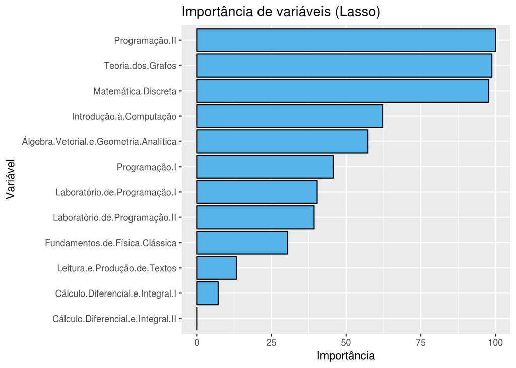

```r
ggplot(varImp(lasso.fit)) +
  geom_bar(stat="identity", fill="#56B4E9", colour="black") +
  labs(title="Importância de variáveis (Lasso)", y="Importância", x="Variável")
```

Compare os dois modelos nos dados de teste em termos de RMSE.

```r
rmse <- function(error) {
    sqrt(mean(error^2))
}

ridge.pred <- predict(ridge.fit, students.test.data)
ridge.rmse <- rmse(ridge.pred - students.test.data$cra)

lasso.pred <- predict(lasso.fit, students.test.data)
lasso.rmse <- rmse(lasso.pred - students.test.data$cra)

ridge.rmse
```

```
## [1] 0.4005705
```

```r
lasso.rmse
```

```
## [1] 0.4019459
```

Comparando os dois modelos nos dados de teste, temos que o método ridge apresentou um RMSE ligeiramente menor do que o método lasso, a saber, 0.4005705 (ridge) contra 0.4019459 (lasso).

De uma forma geral, o Lasso tem um comportamento bastante similar com a regressão ridge em termos de variância e BIAS. O Lasso produz resultados melhores do que o ridge em casos que somente poucos preditores têm coeficientes significantes e o restante possuem coeficientes muito próximos de ou iguais a zero. A regressão ridge obterá resultados melhores que a lasso em casos que a variável de resposta possui muitos preditores e todos com valores na mesma faixa.

Re-treine o melhor modelo (dessa vez nos dados de treino sem validação cruzada) e reporte o RMSE no teste.

Vamos retreinar o modelo ridge sem utilizar a validação cruzada.

```r
ridge.fit.no.cv <- train(form = cra ~.,
                   data = students.train.data %>% select(-matricula),
                   method = 'ridge',
                   tuneGrid = lambdaGrid,
                   preProcess = c('scale', 'center'),
                   na.action = na.omit)

ridge.no.cv.pred <- predict(ridge.fit.no.cv, students.test.data)
ridge.no.cv.rmse <- rmse(ridge.no.cv.pred - students.test.data$cra)
ridge.no.cv.rmse
```

```
## [1] 0.4004168
```

Sem o uso da validação cruzada, o RMSE teve uma queda desprezível. Isso acontece porquê a validação cruzada (cross validation) não altera em nada o resultado dos testes. A validação cruzada pode ser utilizada para estimar o erro de teste associado a um determinado método de aprendizado estatístico e com isso podemos melhor avaliar a performance do modelo gerado, ou selecionar um nível apropriado de flexibilidade.s

Use ou tente melhorar o seu modelo para prever os dados de teste que disponibilizamos por meio da plataforma Kaggle:

Para melhorar o modelo eu tentei várias abordagens. Primeiro tentei introduzir variáveis que eu achei que poderiam explicar o cra, dentre estas, a média do aluno em disciplinas que envolvam muita matemática, a média do aluno em disciplnas focadas em programação e o cra do aluno para os dois primeiros semestres. Essa abordagem não funcionou. O RMSE nos dados de validação continuou igual ou piorou. Outra abordagem foi tentar retirar algumas variávies do modelo, mas esta também não melhorou o RMSE. O que realmente melhorou o RMSE foi encontrar um novo método de regressão que seja melhor modele os dados. Esse método foi o Partial Least Squares (PLS), que é um método de redução de dimensão.

```r
students.train.data <- students.train.data %>% select(-matricula)
# pcr, pls, gpls
# pls foi o melhor
pls.fit <- train(form = cra ~.,
                 data = students.train.data,
                 method = 'pls',
                 preProcess = c('scale', 'center'),
                 trControl = fitControl)

pls.pred <- predict(pls.fit, students.test.data, ncomp=7)
pls.rmse <- rmse(pls.pred - students.test.data$cra)
pls.rmse
```

```
## [1] 0.3660131
```